# EP008

Equipo 6

2025-05-15

## Pregunta 1

Propongan una pregunta de investigación original, que involucre la comparación de una frecuencia de un evento o característica en dos grupos independientes (más abajo se dan unos ejemplos). Fijando una semilla propia, seleccionen una muestra aleatoria de hogares (100 < n < 150) y respondan la pregunta propuesta utilizando una prueba de permutaciones Monte Carlo. Indicación: creen su propio código, específicamente para este problema, no usen directamente el script del apunte.

### Pregunta propuesta

La proporción de hogares en la Región Metropolitana (`region`) afiliados a algún sistema de pensiones (`o28`) pero ¿es similar entre quienes han completado una carrera profesional y quienes han cursado un técnico de nivel superior (`e6a`)?.

### Respuesta:

En primer lugar se realizará la carga de datos y la filtración para trabajar con los datos de interés:

```r
library(dplyr)
library(WRS2)

datos <- read.csv2("EP08 Datos CASEN 2017.csv", sep = ",")
estados_p1 <- c("Profesional Completo (Carreras 4 o más años)", "Técnico Nivel Superior Completo (Carreras 1 a 3 años)")

set.seed(137)

# Filtrar datos sin modificar la variable o28
datos_1 <- datos %>%
  filter(region == "Región Metropolitana de Santiago") %>%
  filter(e6a %in% estados_p1) %>%
  filter(o28 %in% c("Sí", "No")) %>%
  filter(!is.na(o28), !is.na(e6a)) %>%
  select(e6a, o28) %>%
  sample_n(125)
```

Se debe entonces calcular la diferencia entre las proporciones de quienes completaron su carrera profesional y quienes completaron un técnico de nivel superior que están afiliados a un sistema de pensiones.

```r
# Crear tabla de contingencia
tabla_afiliacion <- table(datos_1$e6a, datos_1$o28)

# Mostrar la tabla con nombres legibles
dimnames(tabla_afiliacion) <- list(
  "Nivel educacional" = c("Profesional", "Técnico"),
  "Afiliado" = c("No", "Sí")
)
print(tabla_afiliacion)
```

```
##                  Afiliado
## Nivel educacional No Sí
##       Profesional 10 83
##       Técnico      5 27
```

```r
# Calcular proporciones
prop_profesional <- tabla_afiliacion["Profesional", "Sí"] / sum(tabla_afiliacion["Profesional", ])
prop_tecnico <- tabla_afiliacion["Técnico", "Sí"] / sum(tabla_afiliacion["Técnico", ])

cat("Profesionales:", round(prop_profesional, 4), "\n")
```

```
## Profesionales: 0.8925
```

```r
cat("Técnicos:", round(prop_tecnico, 4), "\n")
```

```
## Técnicos: 0.8438
```

```r
# Diferencia observada
diff_obs <- round(prop_profesional - prop_tecnico, 4)
cat("\nDiferencia de proporciones observada:", diff_obs, "\n")
```

```
##
## Diferencia de proporciones observada: 0.0487
```

Se definen entonces las hipótesis a trabajar:

Hipótesis nula: Las proporciones entre las personas completaron una carrera profesional ($P_p$) y las personas terminaron un técnico ($P_t$) que son de la Región Metropolitana y están afiliados a algún sistema de pensiones son iguales, es decir, $H_0: P_p = P_t$.

Hipótesis alternativa: Las proporciones entre quienes completaron una carrera profesional ($P_p$) y quienes terminaron un técnico ($P_t$) que son de la Región Metropolitana y están afiliados a algún sistema de pensione son diferentes, es decir, $H_A: P_p \neq P_t$.

Para esto se utilizará una prueba de permutaciones Monte Carlo, que permite calcular el valor p de la diferencia observada entre las proporciones de los dos grupos. Se utilizará un número de remuestras de 999 y un nivel de significancia $\alpha = 0.05$.

```r
niveles_originales <- datos_1$e6a
afiliacion <- datos_1$o28

# Crear R permutaciones (cambiando los grupos, pero no los resultados)
R <- 999
set.seed(137)
n1 <- nrow(datos_1)
diferencias_perm <- numeric(R)

for (i in 1:R) {
  permutacion <- sample(niveles_originales)  # permutar los niveles educativos
  tabla_perm <- table(permutacion, afiliacion)

  # Asegurar consistencia en el orden
  prop1 <- tabla_perm["Profesional Completo (Carreras 4 o más años)", "Sí"] /
           sum(tabla_perm["Profesional Completo (Carreras 4 o más años)", ])
  prop2 <- tabla_perm["Técnico Nivel Superior Completo (Carreras 1 a 3 años)", "Sí"] /
           sum(tabla_perm["Técnico Nivel Superior Completo (Carreras 1 a 3 años)", ])

  diferencias_perm[i] <- prop1 - prop2
}

# Intervalo de confianza al 95%
ic <- quantile(diferencias_perm, c(0.025, 0.975))

# Valor p (prueba bilateral)
p_valor <- (sum(abs(diferencias_perm) >= abs(diff_obs)) + 1) / (R + 1)

cat("IC 95%:", round(ic[1], 4), "a", round(ic[2], 4), "\n")
```

```
## IC 95%: -0.1193 a 0.1327
```

```r
cat("Valor p:", round(p_valor, 4), "\n")
```

```
## Valor p: 0.523
```

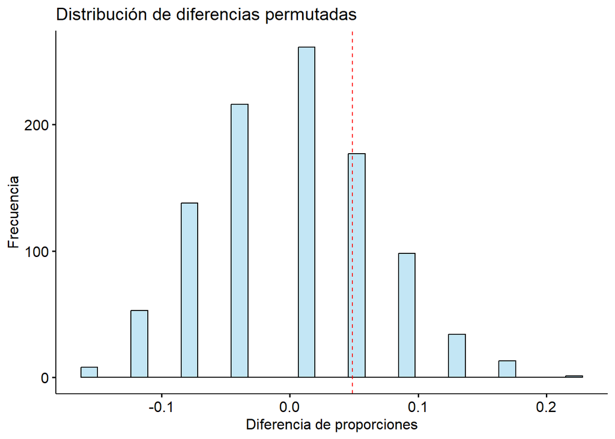

```r
library(ggpubr)

df_plot <- data.frame(dif = diferencias_perm)

gghistogram(df_plot, x = "dif", bins = 30, fill = "skyblue",
            title = "Distribución de diferencias permutadas",
            xlab = "Diferencia de proporciones",
            ylab = "Frecuencia") +
  geom_vline(xintercept = diff_obs, color = "red", linetype = "dashed")
```

Veamos que, se obtiene un valor p de 0.523, al ser este mayor a α, se puede decir entonces con un 95% de confianza que se falla al rechazar la hipótesis nula, por lo que no hay evidencia suficiente para afirmar que las proporciones de hogares en la Región Metropolitana que están afiliados a algún sistema de pensiones son diferentes entre quienes han completado una carrera profesional y quienes han cursado un técnico de nivel superior. Teniendo un intervalo de confianza de [-0.1193 a 0.1327]

## Pregunta 2

Propongan una pregunta de investigación original, que involucre la comparación de las medias de más de dos grupos independientes (más abajo se dan unos ejemplos). Fijando una semilla distinta a la anterior, seleccionen una muestra aleatoria de hogares (200 < n < 300) y respondan la pregunta propuesta utilizando bootstrapping. Solo por ejercicio académico, aplique un análisis post-hoc con bootstrapping aunque este no fuera necesario. Indicación: consideren que el análisis post-hoc debe hacerse con las mismas remuestras usadas para la prueba ómnibus.

### Pregunta propuesta

La cantidad de hijos promedio en los hogares (`s4`) de la región Metropolitana (`region`) ¿es similar entre personas casadas, en pareja sin unión civil, y separadas? (`ecivil`)?

Denotando $C$, $S$, y $P$ como los estados civiles “Casado(a)”, “Separado(a)” y “Conviviente o pareja sin acuerdo de unión civil” respectivamente; y $\mu_{ec}$ como la cantidad de hijos promedio en los hogares de la región Metropolitana para el estado civil $ec$, definimos las hipótesis a contrastar para el caso:

- $H_0$: La cantidad de hijos promedio en los hogares de la región Metropolitana es similar entre personas casadas, separadas, y en pareja sin unión civil. Matemáticamente $\mu_C = \mu_P = \mu_S$
- $H_A$: Al menos una de las cantidades de hijos promedio es diferente entre los distintos grupos. Matemáticamente $\exists\ ec_1, ec_2 \in \{C, P, S\}, ec_1 \neq ec_2 \ |\ \mu_{ec_1} \neq \mu_{ec_2}$

```r
library(dplyr)
library(WRS2)

datos <- read.csv2("EP08 Datos CASEN 2017.csv", sep = ",")
estados_p2 <- c("Casado(a)", "Conviviente o pareja sin acuerdo de unión civil", "Separado(a)")

# filtrar datos para pregunta 2
datos_p2 <- datos %>%
  filter(region == "Región Metropolitana de Santiago") %>%
  select(s4, ecivil) %>%
  filter(ecivil %in% estados_p2) %>%
  filter(!is.na(ecivil), !is.na(s4))

# assert tipos de dato
datos_p2$s4 = as.numeric(datos_p2$s4)
datos_p2$ecivil = as.factor(datos_p2$ecivil)

# muestreo aleatorio inicial de n = 250
set.seed(137)
muestra_p2 <- datos_p2 %>% sample_n(250)
```

Analizando las distribuciones de la cantidad de hijos en los tres estados civiles:

```r
library(ggpubr)
library(gridExtra)
```

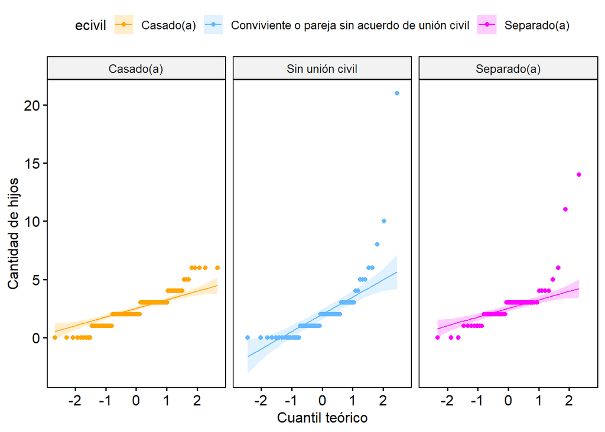

```r
# QQ plots para la cantidad de hijos en los tres estados civiles
qqplots_p2 <- ggqqplot(muestra_p2, x = "s4",
         facet.by = "ecivil",
         palette = c("orange", "steelblue1", "magenta"),
         color = "ecivil",
         xlab = "Cuantil teórico",
         ylab = "Cantidad de hijos",
         panel.labs = list(ecivil = c("Casado(a)", "Sin unión civil", "Separado(a)")),
         )
qqplots_p2
```

Vemos que los datos presentan desviaciones notables en el extremo derecho, sobretodo para las personas en pareja sin unión civil, presentando cantidades de valores atípicos (incluso un caso con 21 hijos), caso similar para las personas separadas.

Para confirmar sospechas comprobamos la normalidad de los datos para cada grupo de estado civil utilizando la prueba de Shapiro-Wilk.

```r
p2_shapiros <- by(muestra_p2$s4, muestra_p2$ecivil, shapiro.test)

# mostrar resultados solo para los estados civiles pertinentes
p2_shapiro_p <- p2_shapiros[estados_p2]
p2_shapiro_p
```

```
## $`Casado(a)`
##
##  Shapiro-Wilk normality test
##
## data:  dd[x, ]
## W = 0.91945, p-value = 8.908e-07
##
##
## $`Conviviente o pareja sin acuerdo de unión civil`
##
##  Shapiro-Wilk normality test
##
## data:  dd[x, ]
## W = 0.60844, p-value = 2.254e-12
##
##
## $`Separado(a)`
##
##  Shapiro-Wilk normality test
##
## data:  dd[x, ]
## W = 0.67077, p-value = 3.274e-09
```

Habiendo obtenido un valor p muy pequeño para cada distribución; rechazamos la hipótesis nula de la prueba de Shapiro, indicando que los datos para las muestras mencionadas no parecen seguir una distribución normal.

Se procederá con la alternativa robusta a ANOVA, que no requiere la suposición de normalidad. Particularmente, la versión que utiliza bootstrapping para estimar el valor p y el tamaño del efecto. Viendo las condiciones de este procedimiento:

- **Observaciones independientes**: Las observaciones son independientes entre sí, ya que cada hogar es único y no se relaciona con algún otro.
- **Muestras independientes:** Las muestras son independientes entre sí, ya que cada grupo de estado civil es diferente y no se relaciona con otro grupo.
- **Escala de intervalos iguales:** Al ser cantidad de hijos, la variable estudiada cumple con esta condición.

Definiremos 999 remuestras; y un porcentaje de poda $\gamma = 0,2$, para eliminación de los valores extremos mencionados anteriormente.

```r
gamma = 0.2
nboot = 999
una_via_bt <- t1waybt(s4 ~ ecivil, data = muestra_p2, tr = gamma, nboot = nboot)
print(una_via_bt)
```

```
## Call:
## t1waybt(formula = s4 ~ ecivil, data = muestra_p2, tr = gamma,
##     nboot = nboot)
##
## Effective number of bootstrap samples was 999.
##
## Test statistic: 5.5634
## p-value: 0.00601
## Variance explained: 0.135
## Effect size: 0.367
```

Aplicando el método obtenemos un valor $p = 0.006006$, menor al nivel de significancia establecido $\alpha = 0,05$, por lo que rechazamos $H_0$ en favor de $H_A$. En conclusión, podemos afirmar con un 95% de confianza que la cantidad de hijos promedio en los hogares de la región Metropolitana es diferente para al menos uno de los estados civiles analizados.

Con un tamaño del efecto de $0.3671039$, considerado entre mediano y grande, podemos además decir que la diferencia entre los grupos es razonablemente significativa.

Procediendo con el análisis post-hoc para hallar qué grupo difiere:

```r
posthoc_rb <- mcppb20(s4 ~ ecivil, data = muestra_p2, tr = gamma, nboot = nboot)
print(posthoc_rb)
```

```
## Call:
## mcppb20(formula = s4 ~ ecivil, data = muestra_p2, tr = gamma,
##     nboot = nboot)
##
##                                                                   psihat
## Separado(a) vs. Conviviente o pareja sin acuerdo de unión civil  0.77336
## Separado(a) vs. Casado(a)                                       -0.12372
## Conviviente o pareja sin acuerdo de unión civil vs. Casado(a)   -0.89708
##                                                                 ci.lower
## Separado(a) vs. Conviviente o pareja sin acuerdo de unión civil  0.23086
## Separado(a) vs. Casado(a)                                       -0.57615
## Conviviente o pareja sin acuerdo de unión civil vs. Casado(a)   -1.52919
##                                                                 ci.upper
## Separado(a) vs. Conviviente o pareja sin acuerdo de unión civil  1.29717
## Separado(a) vs. Casado(a)                                        0.40955
## Conviviente o pareja sin acuerdo de unión civil vs. Casado(a)   -0.25806
##                                                                 p-value
## Separado(a) vs. Conviviente o pareja sin acuerdo de unión civil  0.0000
## Separado(a) vs. Casado(a)                                        0.5045
## Conviviente o pareja sin acuerdo de unión civil vs. Casado(a)    0.0020
```

Vemos que el valor p ajustado para la comparación entre los grupos de “sin unión civil” y los demás estados civiles es menor a 0,05. Además, viendo las diferencias de las medias truncadas, tenemos:

$$\begin{align*}
\bar{x_S}^t - \bar{x_P}^t &= 0.773 \text{ hijos} \\
\bar{x_P}^t - \bar{x_C}^t &= -0.897 \text{ hijos}
\end{align*}$$

Indicando que las personas separadas tienen un promedio de 0.773 hijos más que las personas en pareja sin unión civil, y que las personas en pareja sin unión civil tienen un promedio de 0.897 hijos menos que las personas casadas.

Por lo que podemos concluir que, sin considerar los casos extremos, la cantidad de hijos promedio en los hogares de la región Metropolitana es menor para personas en pareja sin unión civil que para personas casadas y separadas.